# Logistics of Teaching with R

ECOTS Workshop, May 22, 2014

Every course we teach has logistics. The way we handle logistics has changed over time.

**Logistics Techniques**

- Lecture / blackboard for broadcasting information
- Mimeograph -> Photocopy for providing a syllabus, etc.
- Floppy disks, “H: drive” for distributing files
- Computer lab machines -> student-owned laptops
- Links to HTML files
- Course specific web sites
- Course support software (e.g. Moodle)

Many old-time techniques are still good, but some of them are not well suited to teaching with computation and not well integrated with R.

## Logistical Needs

Here are some basic areas needed for just about every R-based class.

1. Providing R
2. Distributing data files
3. Distributing class notes
4. Distributing R commands

These same areas apply to other software: JMP, Python, Matlab, Mathematica, etc.

## Providing R

Some Options:

- Install R/RStudio on lab machines
- Install R/RStudio on student machines
- Use an R/RStudio server

### Many beginning students: Use a server

Every student has a Facebook account, so they already have access to the hardware they need.

#### Advantages

- No student set up
- Everyone has exactly the same interface
- Dogs can’t possible eat their computer.
- Students can share their account with you — you can see what’s wrong to help them.
- Update of version and packages is centralized

#### Disadvantages

- Possible load problems
  - Hundreds of students simultaneously in class
  - Thousands of students asynchronously
- Working with your IT Department. Some are great, others have limited resources.
  - Work-around, as necessary. A server can be set up on the Cloud, e.g. Amazon Web Services. Good documentation of process for sys-admins.

## Distributing Data Files

- Students download files and use basic R functions to read them in, e.g. `read.csv()`
- Give students links to data files on web server. Again, use the basic R functions, e.g.

  ```r
  read.csv("http://dl.dropboxusercontent.com/u/5098197/StatisticalModeling/mydata1.csv")
  ```

- Functions for reading in files with short names, e.g. `mosaic::fetchData()`
- Existing packages, e.g. `data(Galton, package='mosaic')`
- Shared, editable files (e.g. for group projects)

and even …

- Your own package for your own course.

### Students Download Files

**Problems**

- Students may not put files where they should.
- Uploading files to RStudio Server can be confusing. Students don’t understand that the server is another machine running another operating system.
- Students will use the wrong R function.
- Updating is a nightmare.

**Advantages**

NONE

## Links to Data Files on Web Server

Of course, that’s how you would distribute files for download.

Rather than posting a link to the file, post the **command** for reading in the file to the current data session.

```r
todaysData <- read.csv(file="http://dl.dropboxusercontent.com/u/5098197/StatisticalModeling/mydata1.csv")
```

Students cut-and-paste the command from course web site to their R session.

**TIPS**

Make sure the protocol is `http://`, not `https://`

Use tinyurl.com` to translate your long URL to a short one.

```r
fetchData("http://tinyurl.com/q9pbn7t")
```

```
## Complete file name given.  No searching necessary.
```

```
##       Who Age
## 1    Bill   3
## 2 Charley   4
## 3   Debby   5
```

**Advantages**

- Easy to find, use, and to update data.
- Posting command minimizes possibilities for typing mistakes.
- Many datasets already on book sites, e.g. Lock^5

## Functions for reading in files with short names

Set up a web repository for files. Write a function that looks up short names on that repository.

Example:

```r
G <- mosaic::fetchData("Dome.csv")
```

```
## Retrieving from http://www.mosaic-web.org/go/datasets/Dome.csv
```

**Advantages**

- Easy to use new data sets in class: one step process

**Disadvantages**

- Writing such a function is not trivial for newbies
- `mosaic::fetchData()` doesn’t automatically connect to **your** repository, just the `mosaic` one.

## Existing Packages

Packages are the standard way for distributing R software. They also provide facilities for data, for notes, and for Rmd templates.

The data set you want to use may already exist in a CRAN or other package.

Command to access the data:

- Loaded packages : e.g. `data(Galton)` or sometimes just `Galton`
- Installed but unloaded packages: `data(BOD, package='datasets')`

Finding the data you want:

- Look at packages on CRAN etc. Get list by naming the package, e.g.

  ```
  data(package='datasets')
  ```

  There are thousands of datasets available.

## Shared, Simultaneously Editable Data

For student project collaborations, or …

When collecting data from the class, let the students enter it for you.

- A nice way to teach about the organization of data. You can see and show the class as it’s being mis-entered.

### Google Spreadsheets

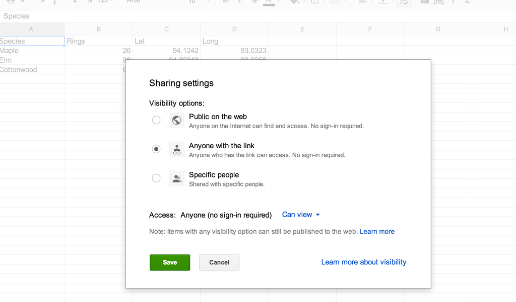

4. Post that link on your web page so students can get to the file: https://docs.google.com/spreadsheet/ccc?key=0Am13enSalO74dFBPVVZyTndFWlBndVVVSmpENGpPRFE&usp=sharing
   - Go to `tinyurl.com` if you want to translate your link to a smaller form. Here’s this one: http://tinyurl.com/pgwlljs
5. “Publish” the spreadsheet to the web. (File/Publish to Web)
6. Get the link for the file in CSV format.

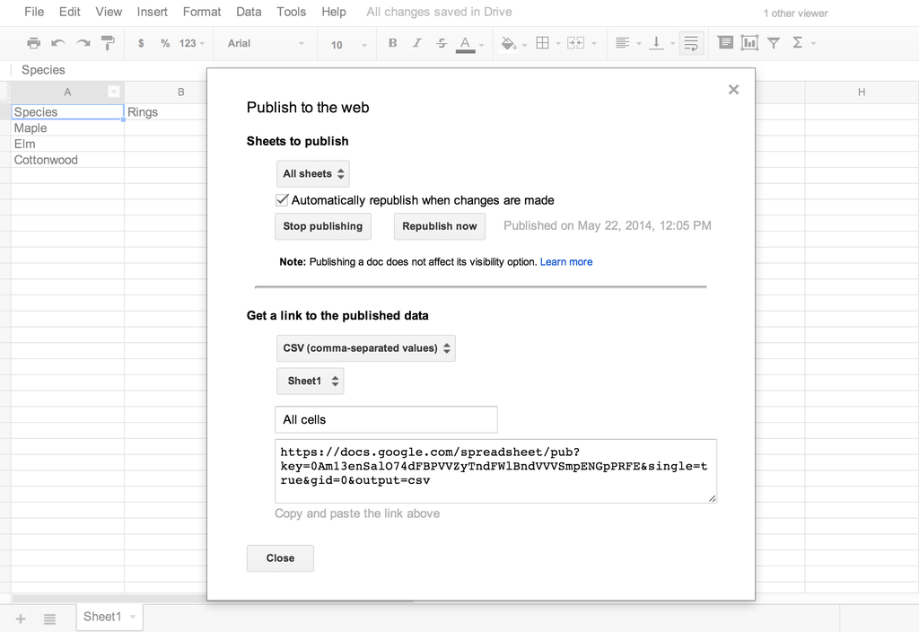

7. Post that link/command. Use `mosaic::fetch`, e.g.

```r
require(mosaic)
ECOTS <- fetchGoogle("https://docs.google.com/spreadsheet/pub?key=0Am13enSalO74dFBPVVZyTndFWlBndVVVSmpENGpPRFE&single=true&gid=0&output=csv")
```

## Your own R Package

It’s not hard to make a simple R package. Include your data in the `data` directory of the package.

Example: * The sources https://github.com/dtkaplan/ECOTS-ICOTS-2014/tree/master/ECOTS/CourseR * Installation via

````
```r
require(devtools)
install_github("dtkaplan/ECOTS-ICOTS-2014/ECOTS/CourseR")
help(dataDocExample)
```
````

## Distributing Class Notes

Use R/Markdown to write notes.

Options:

- Publish the notes to Rpubs.com and post link on your website
  - Example: http://rpubs.com/dtkaplan/ecots-modeling
  - Example: http://rpubs.com/dtkaplan/ECOTS-logistics
- Keep the html files on your web server.  
  Even better: Keep the sources there so that the notes will be updated automatically when you change them. Even better: Keep your RStudio Project on the web server.
- Use an RStudio project linked to GitHub. This is very powerful, but has a steep learning curve.

## Distributing R Commands

Suggestion: Use R Markdown and distribute the commands just like your class notes. Give a link to the `.Rmd` file.

Have students copy and paste from their browser into the RStudio editor, and use “Chunks/Run All”. That will source the code.

### Emerging Techniques

RStudio has “templates.” These are currently distributed from packages.

From the `CourseR` package.

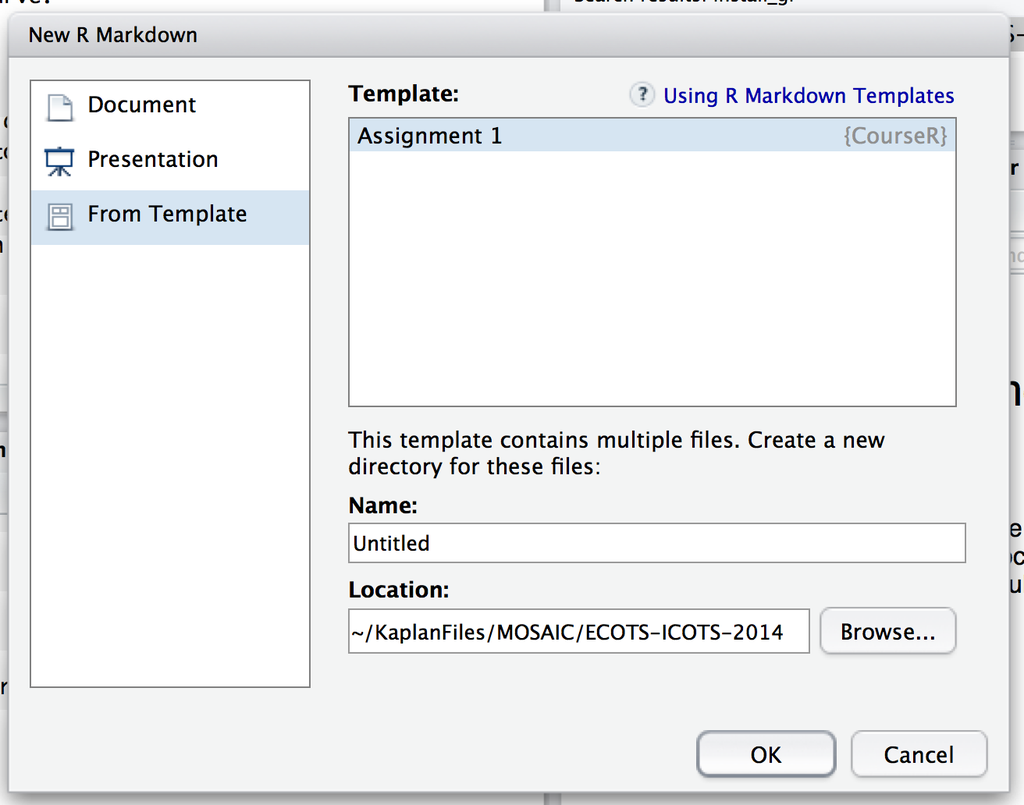

## Time for a Teach-with-R package

Make it easy for instructors to set up the logistics.

Interested in helping?